# STA141A Project report

4-4 Summary Statistics

```r
library(dplyr)
library(ggplot2)
library(stringr)

session <- list()

for(i in 1:18) {
  session[[i]] <- readRDS(paste('C:/Users/admin/Documents/Data/session', i, '.rds', sep=''))
}

all_sessions <- bind_rows(session, .id = "session_id") %>%
  mutate(spike_count = rowSums(select(., starts_with("spks")), na.rm = TRUE))

if (nrow(all_sessions) == 0) {
  stop("Error: No data found in all_sessions.")
}

summary_statistics <- all_sessions %>%
  group_by(mouse_name, date_exp) %>%
  summarize(
    mean_spike_count = mean(spike_count, na.rm = TRUE),
    median_spike_count = median(spike_count, na.rm = TRUE),
    sd_spike_count = sd(spike_count, na.rm = TRUE),
    min_spike_count = min(spike_count, na.rm = TRUE),
    max_spike_count = max(spike_count, na.rm = TRUE),
    count = n(),
    .groups = "drop"
  )

if (nrow(summary_statistics) == 0) {
  warning("No summary statistics calculated. Check if the data contains valid entries.")
} else {
  print(summary_statistics)

  output_path <- file.path("C:", "Users", "admin", "Documents", "Data", "summary_statistics.csv")

  if (!dir.exists(dirname(output_path))) {
    stop("Error: Directory does not exist.")
  } else {
    write.csv(summary_statistics, output_path, row.names = FALSE)
  }
}
```

```
## # A tibble: 1 × 8
##   mouse_name date_exp   mean_spike_count median_spike_count sd_spike_count
##   <chr>      <date>                <dbl>              <dbl>          <dbl>
## 1 Cori       2025-02-27           20031.             20068.           139.
## # ℹ 3 more variables: min_spike_count <dbl>, max_spike_count <dbl>, count <int>
```

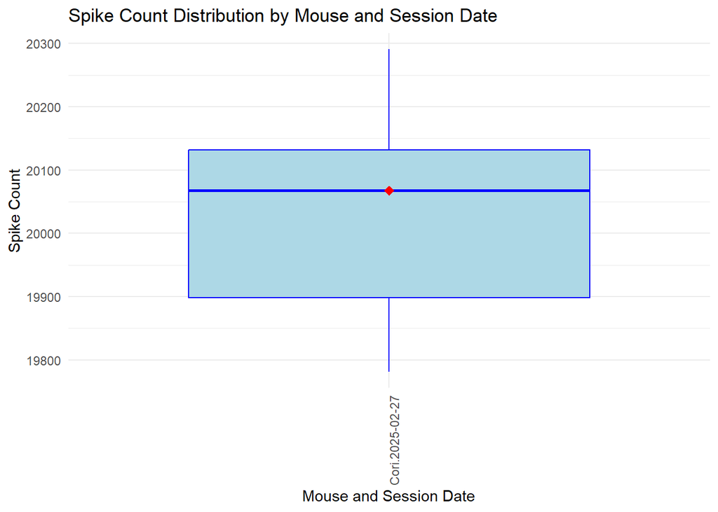

```r
ggplot(all_sessions, aes(x = interaction(mouse_name, date_exp), y = spike_count)) +
  geom_boxplot(fill = "lightblue", color = "blue") +
  geom_point(data = summary_statistics, aes(x = interaction(mouse_name, date_exp), y = median_spike_count),
             color = "red", size = 3, shape = 18) +
  labs(title = "Spike Count Distribution by Mouse and Session Date",
       x = "Mouse and Session Date",
       y = "Spike Count") +
  theme_minimal() +
  theme(axis.text.x = element_text(angle = 90, hjust = 1)) +
  scale_x_discrete(breaks = unique(interaction(all_sessions$mouse_name, all_sessions$date_exp)))
```

Distribution: The graph shows that there are steady responses within the 19,900–20,200 range, which is where the spike count is dispersed.

Outliers: The graph shows no obvious outliers, suggesting that Cori Mouse’s replies are reliable.

5. Data integration

5.1 Prepare Your Data

```r
library(dplyr)

session_dir <- "C:/Users/admin/Documents/Data"

session <- list()
for (i in 1:18) {
  file_path <- file.path(session_dir, paste('session', i, '.rds', sep=''))

  if (file.exists(file_path)) {
    session[[i]] <- tryCatch({
      readRDS(file_path)
    }, error = function(e) {
      warning(paste("Error reading file:", file_path, " - ", e$message))
      NULL
    })
  } else {
    warning(paste("File not found:", file_path))
  }
}

if (length(session) > 0) {
  data <- do.call(rbind, session)
} else {
  stop("No valid session data found.")
}

# data_numeric 정의
data_numeric <- data %>%
  select(starts_with("spks"))

print(str(data))
```

```
## 'data.frame':    1800 obs. of  4005 variables:
##  $ mouse_name    : chr  "Cori" "Cori" "Cori" "Cori" ...
##  $ date_exp      : Date, format: "2025-02-27" "2025-02-27" ...
##  $ feedback_type : num  1 -1 -1 -1 1 -1 1 1 1 1 ...
##  $ contrast_left : num  0.791 0.939 0.136 0.163 0.445 ...
##  $ contrast_right: num  0.9329 0.166 0.0836 0.8936 0.3546 ...
##  $ spks.1        : int  5 5 5 5 5 5 5 5 5 5 ...
##  $ spks.2        : int  9 9 9 9 9 9 9 9 9 9 ...
##  $ spks.3        : int  4 4 4 4 4 4 4 4 4 4 ...
##  $ spks.4        : int  3 3 3 3 3 3 3 3 3 3 ...
##  $ spks.5        : int  4 4 4 4 4 4 4 4 4 4 ...
##  $ spks.6        : int  3 3 3 3 3 3 3 3 3 3 ...
##  $ spks.7        : int  4 4 4 4 4 4 4 4 4 4 ...
##  $ spks.8        : int  4 4 4 4 4 4 4 4 4 4 ...
##  $ spks.9        : int  7 7 7 7 7 7 7 7 7 7 ...
```

[output cut: 87 more lines]

```r
set.seed(123)
sample_size <- min(1000, nrow(data))
sampled_data <- data[sample(nrow(data), sample_size), ]

print(str(sampled_data))
```

```
## 'data.frame':    1000 obs. of  4005 variables:
##  $ mouse_name    : chr  "Cori" "Cori" "Cori" "Cori" ...
##  $ date_exp      : Date, format: "2025-02-27" "2025-02-27" ...
##  $ feedback_type : num  -1 1 -1 -1 1 -1 1 1 -1 -1 ...
##  $ contrast_left : num  0.182 0.479 0.498 0.25 0.643 ...
##  $ contrast_right: num  0.234 0.586 0.534 0.42 0.186 ...
##  $ spks.1        : int  6 6 4 4 4 4 6 7 4 4 ...
##  $ spks.2        : int  4 4 4 6 4 1 3 9 2 2 ...
##  $ spks.3        : int  6 6 5 3 5 8 6 3 8 8 ...
##  $ spks.4        : int  6 6 7 4 7 7 7 3 8 8 ...
##  $ spks.5        : int  5 5 5 2 5 3 4 3 2 2 ...
##  $ spks.6        : int  5 5 5 2 5 6 7 5 11 11 ...
##  $ spks.7        : int  2 2 6 2 6 4 1 5 7 7 ...
##  $ spks.8        : int  6 6 4 6 4 7 6 4 7 7 ...
##  $ spks.9        : int  6 6 7 2 7 2 2 2 8 8 ...
```

[output cut: 87 more lines]

5.2 Standardize the Data (Normalization or Z-Score)

```r
library(dplyr)

session <- list()
for(i in 1:18) {
  session[[i]] <- readRDS(paste('C:/Users/admin/Documents/Data/session', i, '.rds', sep=''))
}

all_sessions <- bind_rows(session, .id = "session_id")

set.seed(123)
sampled_data <- all_sessions %>%
  sample_n(1000)

data_numeric <- sampled_data %>%
  select(starts_with("spks"))

if (ncol(data_numeric) == 0) {
  stop("No spike count columns found starting with 'spks'.")
}

for (col in colnames(data_numeric)) {
  data_numeric[[col]][is.na(data_numeric[[col]])] <- mean(data_numeric[[col]], na.rm = TRUE)
}

data_standardized <- scale(data_numeric)

data_standardized <- as.data.frame(data_standardized)
colnames(data_standardized) <- colnames(data_numeric)

print(str(data_standardized))
```

```
## 'data.frame':    1000 obs. of  4000 variables:
##  $ spks.1   : num  0.527 0.527 -0.567 -0.567 -0.567 ...
##  $ spks.2   : num  -0.116 -0.116 -0.116 0.725 -0.116 ...
##  $ spks.3   : num  0.4742 0.4742 -0.0857 -1.2053 -0.0857 ...
##  $ spks.4   : num  0.255 0.255 0.735 -0.703 0.735 ...
##  $ spks.5   : num  0.191 0.191 0.191 -1.093 0.191 ...
##  $ spks.6   : num  0.0864 0.0864 0.0864 -1.236 0.0864 ...
##  $ spks.7   : num  -0.789 -0.789 0.699 -0.789 0.699 ...
##  $ spks.8   : num  0.249 0.249 -0.725 0.249 -0.725 ...
##  $ spks.9   : num  0.611 0.611 1.031 -1.069 1.031 ...
##  $ spks.10  : num  0.334 0.334 0.334 -0.895 0.334 ...
##  $ spks.11  : num  0.721 0.721 -0.572 1.367 -0.572 ...
##  $ spks.12  : num  -0.792 -0.792 0.859 1.959 0.859 ...
##  $ spks.13  : num  1.348 1.348 0.357 1.348 0.357 ...
##  $ spks.14  : num  -0.526 -0.526 1.236 2.411 1.236 ...
```

[output cut: 87 more lines]

5.3 Apply PCA

```r
library(dplyr)
library(tidyr)
library(ggplot2)

session <- lapply(1:18, function(i) {
  file_path <- paste0('C:/Users/admin/Documents/Data/session', i, '.rds')
  if (file.exists(file_path)) {
    readRDS(file_path)
  } else {
    NULL
  }
})

combined_data <- bind_rows(session)

numeric_data <- combined_data %>%
  select(where(is.numeric)) %>%
  mutate(across(everything(), ~ replace_na(., mean(., na.rm = TRUE))))

standardized_data <- scale(numeric_data)

pca_result <- prcomp(standardized_data, center = TRUE, scale. = TRUE)

print(summary(pca_result))
```

[output not shown]

[output cut: 1382 more lines]

[output not shown]

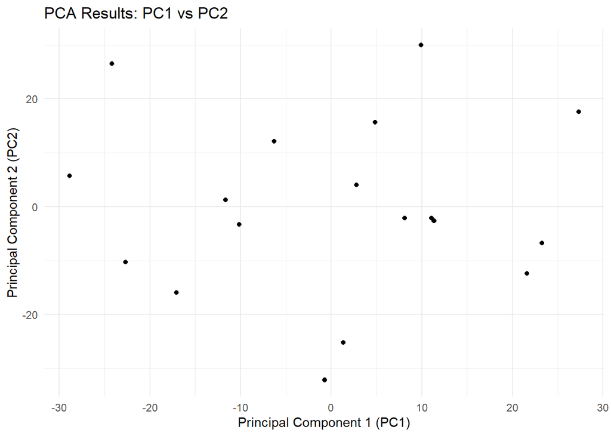

```r
final_data <- cbind(combined_data, pca_result$x)

ggplot(final_data, aes(x = PC1, y = PC2)) +
  geom_point(alpha = 0.5) +
  labs(title = "PCA Results: PC1 vs PC2", x = "Principal Component 1 (PC1)", y = "Principal Component 2 (PC2)") +
  theme_minimal()
```

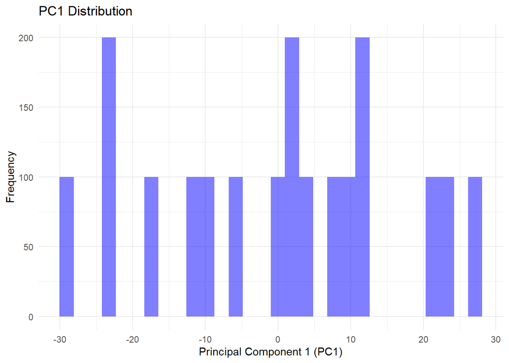

```r
ggplot(final_data, aes(x = PC1)) +
  geom_histogram(bins = 30, fill = 'blue', alpha = 0.5) +
  labs(title = "PC1 Distribution", x = "Principal Component 1 (PC1)", y = "Frequency") +
  theme_minimal()
```

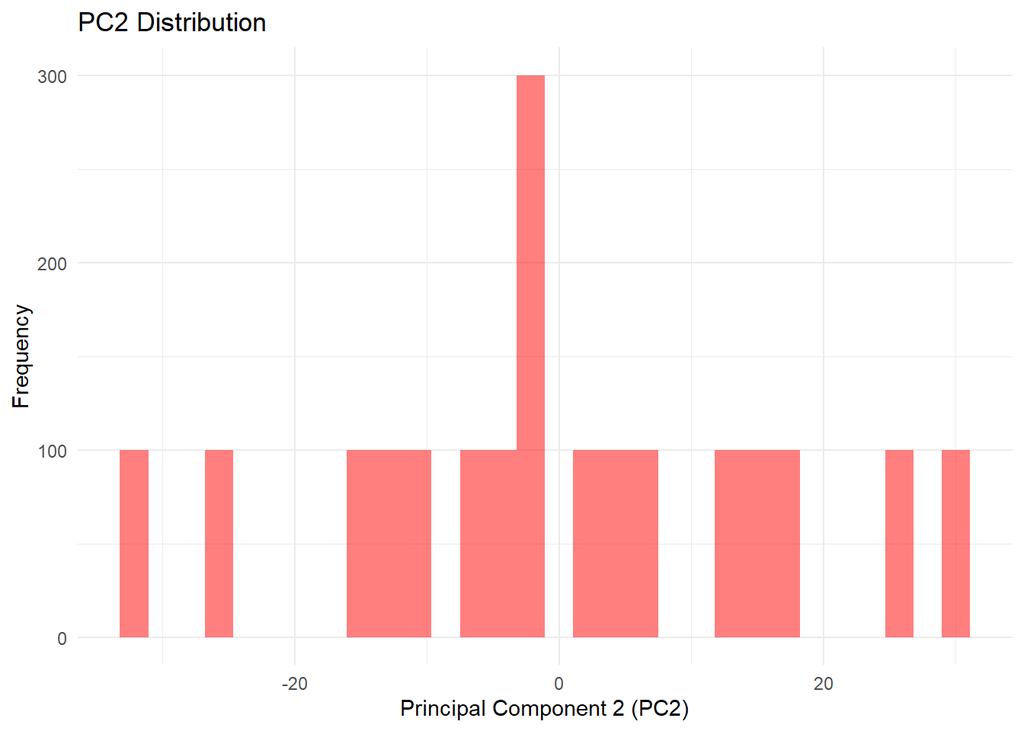

```r
ggplot(final_data, aes(x = PC2)) +
  geom_histogram(bins = 30, fill = 'red', alpha = 0.5) +
  labs(title = "PC2 Distribution", x = "Principal Component 2 (PC2)", y = "Frequency") +
  theme_minimal()
```

Answer: The relationship between Principal Component 1 (PC1) on the X-axis and Principal Component 2 (PC2) on the Y-axis is revealed by the PC1 vs. PC2 scatter plot. The graphic makes it possible to evaluate the distribution of the data overall and highlights regions where observations are closely clustered, which may be a sign of clustering. Finding possible outliers is another benefit of using it; points with extreme values in PC1 or PC2 (such as values below -30 or above 20) might be regarded as outliers. Furthermore, the correlation between PC1 and PC2 may be seen in the scatter plot; a low correlation is indicated by a random distribution, while a strong correlation is suggested by dots aligning in a similar direction.

The histogram clearly illustrates the distribution of PC1 values throughout the dataset in the PC1 distribution. Finding important frequency ranges in the data, like a high frequency in a specific range (like 0–10), might reveal important patterns or traits. Additionally, analyzing the distribution’s skewness can yield important information; if it is asymmetric, it implies that the data for PC1 might be skewed in a specific direction.

Its own histogram, which displays the distribution of PC2 values throughout the dataset, is used to illustrate the PC2 distribution. A high frequency of values around particular locations, like close to 0, might highlight significant data features. The investigation can be further deepened by comparing the distributions of PC1 and PC2, since comparable patterns in their histograms may point to a relationship or connection between the two principal components.

6. Predictive modeling

6.1 Data Preparation and Import

```r
library(dplyr)
library(caret)
```

```r
library(caTools)
library(ggplot2)


session <- list()
for(i in 1:18) {
  session[[i]] = readRDS(paste('C:/Users/admin/Documents/Data/session', i, '.rds', sep=''))
}


train_data <- bind_rows(session[2:17])
test_data <- bind_rows(session[c(1, 18)])

str(train_data)
```

```
## 'data.frame':    1600 obs. of  4005 variables:
##  $ mouse_name    : chr  "Cori" "Cori" "Cori" "Cori" ...
##  $ date_exp      : Date, format: "2025-02-27" "2025-02-27" ...
##  $ feedback_type : num  1 -1 -1 -1 1 -1 -1 1 1 -1 ...
##  $ contrast_left : num  0.238 0.299 0.227 0.373 0.315 ...
##  $ contrast_right: num  0.4767 0.8348 0.0957 0.8829 0.2694 ...
##  $ spks.1        : int  4 4 4 4 4 4 4 4 4 4 ...
##  $ spks.2        : int  4 4 4 4 4 4 4 4 4 4 ...
##  $ spks.3        : int  5 5 5 5 5 5 5 5 5 5 ...
##  $ spks.4        : int  7 7 7 7 7 7 7 7 7 7 ...
##  $ spks.5        : int  5 5 5 5 5 5 5 5 5 5 ...
##  $ spks.6        : int  5 5 5 5 5 5 5 5 5 5 ...
##  $ spks.7        : int  6 6 6 6 6 6 6 6 6 6 ...
##  $ spks.8        : int  4 4 4 4 4 4 4 4 4 4 ...
##  $ spks.9        : int  7 7 7 7 7 7 7 7 7 7 ...
```

[output cut: 86 more lines]

```r
str(test_data)
```

```
## 'data.frame':    200 obs. of  4005 variables:
##  $ mouse_name    : chr  "Cori" "Cori" "Cori" "Cori" ...
##  $ date_exp      : Date, format: "2025-02-27" "2025-02-27" ...
##  $ feedback_type : num  1 -1 -1 -1 1 -1 1 1 1 1 ...
##  $ contrast_left : num  0.791 0.939 0.136 0.163 0.445 ...
##  $ contrast_right: num  0.9329 0.166 0.0836 0.8936 0.3546 ...
##  $ spks.1        : int  5 5 5 5 5 5 5 5 5 5 ...
##  $ spks.2        : int  9 9 9 9 9 9 9 9 9 9 ...
##  $ spks.3        : int  4 4 4 4 4 4 4 4 4 4 ...
##  $ spks.4        : int  3 3 3 3 3 3 3 3 3 3 ...
##  $ spks.5        : int  4 4 4 4 4 4 4 4 4 4 ...
##  $ spks.6        : int  3 3 3 3 3 3 3 3 3 3 ...
##  $ spks.7        : int  4 4 4 4 4 4 4 4 4 4 ...
##  $ spks.8        : int  4 4 4 4 4 4 4 4 4 4 ...
##  $ spks.9        : int  7 7 7 7 7 7 7 7 7 7 ...
```

[output cut: 86 more lines]

6.2 Exploratory Data Analysis

```r
library(dplyr)
library(ggplot2)


feedback_types <- table(unlist(lapply(session, function(x) x$feedback_type)))
print(feedback_types)
```

```
##
##  -1   1
## 912 888
```

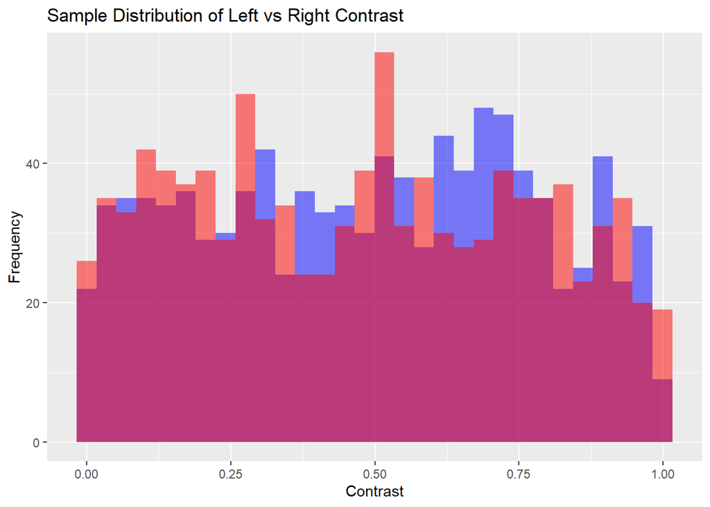

```r
contrast_left <- unlist(lapply(session, function(x) x$contrast_left))
contrast_right <- unlist(lapply(session, function(x) x$contrast_right))


sample_size <- 1000
sample_contrast_left <- sample(contrast_left, sample_size, replace = TRUE)
sample_contrast_right <- sample(contrast_right, sample_size, replace = TRUE)


ggplot() +
  geom_histogram(aes(x = sample_contrast_left), fill = "blue", alpha = 0.5, bins = 30) +
  geom_histogram(aes(x = sample_contrast_right), fill = "red", alpha = 0.5, bins = 30) +
  labs(title = "Sample Distribution of Left vs Right Contrast", x = "Contrast", y = "Frequency")
```

Answer: This histogram contrasts the frequency of left and right differences in the sampled data to provide a better understanding of the mouse’s response to visual stimuli.

The blue bar indicates the frequency of the left contrast, and the red bar indicates the frequency of the right contrast. The purple region represents the overlap between the two contrasts, which illustrates how frequently the two values are comparable.

According to Steinmetz et al. (2019), this histogram has a major impact on the design of the experiment and how the results are interpreted. This emphasizes how crucial stimulus contrast is in determining the behavior and decision-making processes of mice.

6.3 Feature Extraction

```r
library(dplyr)


neuron_counts <- lapply(session, function(x) sapply(x[, grep("^spks\\.", names(x))], length))
trial_counts <- lapply(session, function(x) nrow(x))


extract_spikes <- function(session_data) {
  spks_columns <- session_data[, grep("^spks\\.", names(session_data))]
  spikes_summary <- rowSums(spks_columns, na.rm = TRUE)
  return(spikes_summary)
}

all_spikes <- lapply(session, extract_spikes)


features <- data.frame(
  feedback_type = unlist(lapply(session, function(x) rep(x$feedback_type, nrow(x)))),
  contrast_left = unlist(lapply(session, function(x) rep(x$contrast_left, nrow(x)))),
  contrast_right = unlist(lapply(session, function(x) rep(x$contrast_right, nrow(x)))),
  total_spikes = unlist(all_spikes)
)

# Ensure feedback_type is a factor for classification
features$feedback_type <- as.factor(features$feedback_type)

# Scaling (Z-scores) for the features
features$contrast_left_z <- scale(features$contrast_left)
features$contrast_right_z <- scale(features$contrast_right)
features$total_spikes_z <- scale(features$total_spikes)

# Checking the feature dataframe after scaling
head(features)
```

```
##   feedback_type contrast_left contrast_right total_spikes contrast_left_z
## 1             1     0.7908044     0.93293769        19857       1.0006082
## 2            -1     0.9392104     0.16597524        19857       1.5188601
## 3            -1     0.1362704     0.08358842        19857      -1.2851046
## 4            -1     0.1627777     0.89359183        19857      -1.1925377
## 5             1     0.4445181     0.35456671        19857      -0.2086657
## 6            -1     0.5623402     0.83698156        19857       0.2027834
##   contrast_right_z total_spikes_z
## 1        1.5290613      -1.249495
## 2       -1.1424818      -1.249495
## 3       -1.4294580      -1.249495
## 4        1.3920088      -1.249495
## 5       -0.4855654      -1.249495
## 6        1.1948195      -1.249495
```

6.4 Data Integration Normalization (Z-scores)

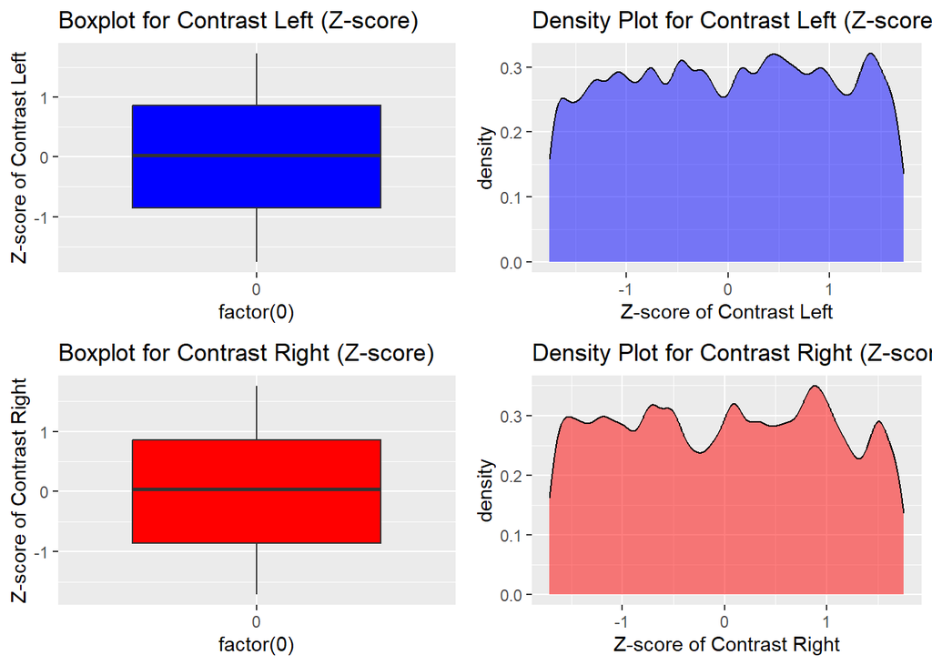

```r
library(ggplot2)
library(gridExtra)
box_contrast_left <- ggplot(features, aes(x = factor(0), y = contrast_left_z)) +
  geom_boxplot(fill = "blue") +
  labs(title = "Boxplot for Contrast Left (Z-score)", y = "Z-score of Contrast Left")

box_contrast_right <- ggplot(features, aes(x = factor(0), y = contrast_right_z)) +
  geom_boxplot(fill = "red") +
  labs(title = "Boxplot for Contrast Right (Z-score)", y = "Z-score of Contrast Right")


density_contrast_left <- ggplot(features, aes(x = contrast_left_z)) +
  geom_density(fill = "blue", alpha = 0.5) +
  labs(title = "Density Plot for Contrast Left (Z-score)", x = "Z-score of Contrast Left")

density_contrast_right <- ggplot(features, aes(x = contrast_right_z)) +
  geom_density(fill = "red", alpha = 0.5) +
  labs(title = "Density Plot for Contrast Right (Z-score)", x = "Z-score of Contrast Right")


grid.arrange(
  box_contrast_left, density_contrast_left,
  box_contrast_right, density_contrast_right,
  nrow = 2, ncol = 2
)
```

Both variables’ boxplots show a uniform distribution with a median near zero. The absence of outliers indicates that the data is consistent and devoid of significant fluctuations.

Overall, there are similar patterns for contrast_left and contrast_right in the Z-score distribution, boxplot, and density plot. The data for both variables is centered around the mean, indicating stable distributions, with little variation and no outliers. Given how similarly they behave in different renderings, there might be a connection between them that merits more research.

7 Model Selection: Logistic Regression with SMOTE for Imbalanced Data

```r
library(caret)
library(DMwR)
```

```r
library(dplyr)
library(ggplot2)
library(pROC)
features$session <- seq_len(nrow(features))

train_data <- features[features$session %in% 2:17, ]
test_data <- features[features$session %in% 1:18, ]

cat("Train data rows: ", nrow(train_data), "\n")
```

```
## Train data rows:  16
```

```r
cat("Test data rows: ", nrow(test_data), "\n")
```

```
## Test data rows:  18
```

```r
cat("Class distribution in train data:\n")
```

```
## Class distribution in train data:
```

```r
print(table(train_data$feedback_type))
```

```
##
## -1  1
##  6 10
```

```r
cat("Class distribution in test data:\n")
```

```
## Class distribution in test data:
```

```r
print(table(test_data$feedback_type))
```

```
##
## -1  1
##  6 12
```

```r
train_data$feedback_type <- as.factor(train_data$feedback_type)
test_data$feedback_type <- as.factor(test_data$feedback_type)

train_data$contrast_combined <- train_data$contrast_left + train_data$contrast_right
test_data$contrast_combined <- test_data$contrast_left + test_data$contrast_right

numeric_columns <- c("contrast_left", "contrast_right", "contrast_left_z", "contrast_right_z", "contrast_interaction")
for (col in numeric_columns) {
    if (col %in% names(train_data)) {
        train_data[[col]] <- as.numeric(train_data[[col]])
        test_data[[col]] <- as.numeric(test_data[[col]])
    }
}

constant_vars <- sapply(train_data, function(x) length(unique(x)) == 1)
if (any(constant_vars)) {
    train_data <- train_data[, !constant_vars]
    test_data <- test_data[, !constant_vars]
}

replace_na_with_mean <- function(data, columns) {
    for (col in columns) {
        if (any(is.na(data[[col]]))) {
            mean_value <- mean(data[[col]], na.rm = TRUE)
            data[[col]][is.na(data[[col]])] <- mean_value
        }
    }
    return(data)
}

train_data <- replace_na_with_mean(train_data, numeric_columns)
test_data <- replace_na_with_mean(test_data, numeric_columns)

pre_proc <- preProcess(train_data[, -which(names(train_data) == "feedback_type")], method = c("center", "scale"))
train_data_scaled <- predict(pre_proc, train_data[, -which(names(train_data) == "feedback_type")])

train_data_scaled$feedback_type <- train_data$feedback_type

train_data_balanced <- SMOTE(feedback_type ~ ., data = train_data_scaled, perc.over = 100, perc.under = 200)

cat("Class distribution in balanced train data:\n")
```

```
## Class distribution in balanced train data:
```

```r
print(table(train_data_balanced$feedback_type))
```

```
##
## -1  1
## 12 12
```

```r
na_count_balanced <- sapply(train_data_balanced, function(x) sum(is.na(x)))
cat("Number of NA values in balanced train data:\n")
```

```
## Number of NA values in balanced train data:
```

```r
print(na_count_balanced)
```

```
##     contrast_left    contrast_right   contrast_left_z  contrast_right_z
##                 0                 0                 0                 0
##           session contrast_combined     feedback_type
##                 0                 0                 0
```

```r
na_columns <- names(na_count_balanced[na_count_balanced > 0])
if (length(na_columns) > 0) {
    for (col in na_columns) {
        if (col %in% names(train_data_balanced)) {
            mean_value <- mean(train_data_balanced[[col]], na.rm = TRUE)
            train_data_balanced[[col]][is.na(train_data_balanced[[col]])] <- mean_value
        }
    }
}

na_count_balanced <- sapply(train_data_balanced, function(x) sum(is.na(x)))
cat("Number of NA values in balanced train data after handling:\n")
```

```
## Number of NA values in balanced train data after handling:
```

```r
print(na_count_balanced)
```

```
##     contrast_left    contrast_right   contrast_left_z  contrast_right_z
##                 0                 0                 0                 0
##           session contrast_combined     feedback_type
##                 0                 0                 0
```

```r
train_control <- trainControl(method = "cv", number = 10, savePredictions = "all")

logistic_model <- train(feedback_type ~ session + contrast_combined,
                        data = train_data_balanced,
                        method = "glm",
                        family = binomial,
                        trControl = train_control)

summary(logistic_model)
```

```
##
## Call:
## NULL
##
## Coefficients:
##                   Estimate Std. Error z value Pr(>|z|)
## (Intercept)         0.0485     0.4229   0.115    0.909
## session             0.2899     0.4326   0.670    0.503
## contrast_combined  -0.1053     0.4995  -0.211    0.833
##
## (Dispersion parameter for binomial family taken to be 1)
##
##     Null deviance: 33.271  on 23  degrees of freedom
## Residual deviance: 32.792  on 21  degrees of freedom
## AIC: 38.792
##
## Number of Fisher Scoring iterations: 4
```

```r
test_data_scaled <- predict(pre_proc, test_data[, -which(names(test_data) == "feedback_type")])

test_data_scaled$contrast_combined <- test_data$contrast_combined

test_data_scaled <- cbind(feedback_type = test_data$feedback_type, test_data_scaled)

na_count_test <- sapply(test_data_scaled, function(x) sum(is.na(x)))
cat("Number of NA values in test data:\n")
```

```
## Number of NA values in test data:
```

```r
print(na_count_test)
```

```
##     feedback_type     contrast_left    contrast_right   contrast_left_z
##                 0                 0                 0                 0
##  contrast_right_z           session contrast_combined
##                 0                 0                 0
```

```r
pred_prob <- predict(logistic_model, newdata = test_data_scaled[, -1], type = "prob")[, 2]

pred_class <- ifelse(pred_prob > 0.5, "1", "-1")

accuracy <- sum(pred_class == test_data_scaled$feedback_type) / nrow(test_data_scaled)
cat("Accuracy:", accuracy, "\n")
```

```
## Accuracy: 0.6111111
```

```r
conf_matrix <- confusionMatrix(factor(pred_class, levels = c("-1", "1")), factor(test_data_scaled$feedback_type))
f1_score <- 2 * (conf_matrix$byClass["Precision"] * conf_matrix$byClass["Recall"]) /
            (conf_matrix$byClass["Precision"] + conf_matrix$byClass["Recall"])
cat("F1 Score:", f1_score, "\n")
```

```
## F1 Score: 0.5333333
```

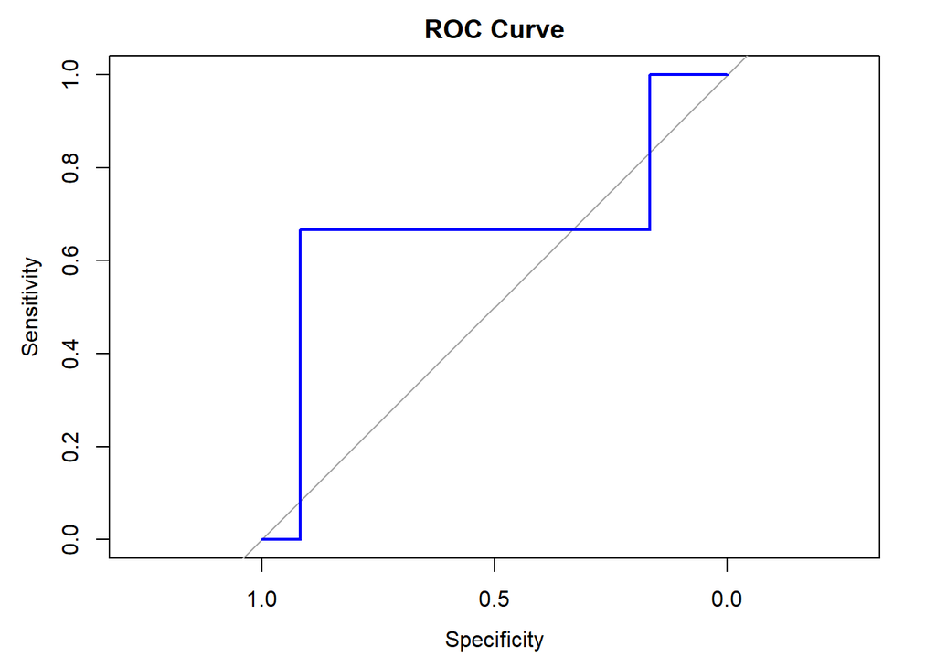

```r
roc_result <- roc(test_data_scaled$feedback_type, pred_prob, levels = c("1", "-1"), direction = ">")

plot(roc_result, main = "ROC Curve", col = "blue", lwd = 2)
```

```r
auc_value <- auc(roc_result)

cat("AUC Value:", auc_value, "\n")
```

```
## AUC Value: 0.6666667
```

7.1 Random Forest Classification with SMOTE for Imbalanced Data

```r
library(caret)
library(DMwR)
library(dplyr)
library(ggplot2)
library(pROC)
library(randomForest)
features$session <- seq_len(nrow(features))

train_data <- features[features$session %in% 2:17, ]
test_data <- features[features$session %in% 1:18, ]

cat("Train data rows: ", nrow(train_data), "\n")
```

```
## Train data rows:  16
```

```r
cat("Test data rows: ", nrow(test_data), "\n")
```

```
## Test data rows:  18
```

```r
cat("Class distribution in train data:\n")
```

```
## Class distribution in train data:
```

```r
print(table(train_data$feedback_type))
```

```
##
## -1  1
##  6 10
```

```r
cat("Class distribution in test data:\n")
```

```
## Class distribution in test data:
```

```r
print(table(test_data$feedback_type))
```

```
##
## -1  1
##  6 12
```

```r
train_data$feedback_type <- as.factor(train_data$feedback_type)

train_data$contrast_combined <- train_data$contrast_left + train_data$contrast_right
test_data$contrast_combined <- test_data$contrast_left + test_data$contrast_right

numeric_columns <- c("contrast_left", "contrast_right", "contrast_left_z", "contrast_right_z", "contrast_interaction")
for (col in numeric_columns) {
    if (col %in% names(train_data)) {
        train_data[[col]] <- as.numeric(train_data[[col]])
        test_data[[col]] <- as.numeric(test_data[[col]])
    }
}

constant_vars <- sapply(train_data, function(x) length(unique(x)) == 1)
if (any(constant_vars)) {
    train_data <- train_data[, !constant_vars]
    test_data <- test_data[, !constant_vars]
}

replace_na_with_mean <- function(data, columns) {
    for (col in columns) {
        if (any(is.na(data[[col]]))) {
            mean_value <- mean(data[[col]], na.rm = TRUE)
            data[[col]][is.na(data[[col]])] <- mean_value
        }
    }
    return(data)
}

train_data <- replace_na_with_mean(train_data, numeric_columns)
test_data <- replace_na_with_mean(test_data, numeric_columns)

pre_proc <- preProcess(train_data[, -which(names(train_data) == "feedback_type")], method = c("center", "scale"))
train_data_scaled <- predict(pre_proc, train_data[, -which(names(train_data) == "feedback_type")])

train_data_scaled$feedback_type <- train_data$feedback_type

train_data_balanced <- SMOTE(feedback_type ~ ., data = train_data_scaled, perc.over = 100, perc.under = 200)

cat("Class distribution in balanced train data:\n")
```

```
## Class distribution in balanced train data:
```

```r
print(table(train_data_balanced$feedback_type))
```

```
##
## -1  1
## 12 12
```

```r
na_count_balanced <- sapply(train_data_balanced, function(x) sum(is.na(x)))
cat("Number of NA values in balanced train data:\n")
```

```
## Number of NA values in balanced train data:
```

```r
print(na_count_balanced)
```

```
##     contrast_left    contrast_right   contrast_left_z  contrast_right_z
##                 0                 0                 0                 0
##           session contrast_combined     feedback_type
##                 0                 0                 0
```

```r
na_columns <- names(na_count_balanced[na_count_balanced > 0])
if (length(na_columns) > 0) {
    for (col in na_columns) {
        if (col %in% names(train_data_balanced)) {
            mean_value <- mean(train_data_balanced[[col]], na.rm = TRUE)
            train_data_balanced[[col]][is.na(train_data_balanced[[col]])] <- mean_value
        }
    }
}

na_count_balanced <- sapply(train_data_balanced, function(x) sum(is.na(x)))
cat("Number of NA values in balanced train data after handling:\n")
```

```
## Number of NA values in balanced train data after handling:
```

```r
print(na_count_balanced)
```

```
##     contrast_left    contrast_right   contrast_left_z  contrast_right_z
##                 0                 0                 0                 0
##           session contrast_combined     feedback_type
##                 0                 0                 0
```

```r
train_control <- trainControl(method = "cv", number = 10, savePredictions = "all")

num_features <- ncol(train_data_balanced) - 1
rf_model <- train(feedback_type ~ .,
                  data = train_data_balanced,
                  method = "rf",
                  trControl = train_control,
                  tuneGrid = expand.grid(mtry = 1:num_features))

summary(rf_model)
```

```
##                 Length Class      Mode
## call               4   -none-     call
## type               1   -none-     character
## predicted         24   factor     numeric
## err.rate        1500   -none-     numeric
## confusion          6   -none-     numeric
## votes             48   matrix     numeric
## oob.times         24   -none-     numeric
## classes            2   -none-     character
## importance         6   -none-     numeric
## importanceSD       0   -none-     NULL
## localImportance    0   -none-     NULL
## proximity          0   -none-     NULL
## ntree              1   -none-     numeric
## mtry               1   -none-     numeric
## forest            14   -none-     list
## y                 24   factor     numeric
## test               0   -none-     NULL
## inbag              0   -none-     NULL
## xNames             6   -none-     character
## problemType        1   -none-     character
## tuneValue          1   data.frame list
## obsLevels          2   -none-     character
## param              0   -none-     list
```

```r
test_data$contrast_combined <- test_data$contrast_left + test_data$contrast_right
test_data$feedback_type <- as.factor(test_data$feedback_type)

test_data_scaled <- predict(pre_proc, test_data[, -which(names(test_data) == "feedback_type")])
test_data_scaled$contrast_combined <- test_data$contrast_combined

test_data_scaled <- cbind(feedback_type = test_data$feedback_type, test_data_scaled)

na_count_test <- sapply(test_data_scaled, function(x) sum(is.na(x)))
cat("Number of NA values in test data:\n")
```

```
## Number of NA values in test data:
```

```r
print(na_count_test)
```

```
##     feedback_type     contrast_left    contrast_right   contrast_left_z
##                 0                 0                 0                 0
##  contrast_right_z           session contrast_combined
##                 0                 0                 0
```

```r
pred_prob <- predict(rf_model, newdata = test_data_scaled[, -1], type = "prob")[, 2]

pred_class <- ifelse(pred_prob > 0.5, "1", "-1")

accuracy <- sum(pred_class == test_data_scaled$feedback_type) / nrow(test_data_scaled)
cat("Accuracy:", accuracy, "\n")
```

```
## Accuracy: 0.8333333
```

```r
conf_matrix <- confusionMatrix(factor(pred_class, levels = c("-1", "1")), factor(test_data_scaled$feedback_type))
f1_score <- 2 * (conf_matrix$byClass["Precision"] * conf_matrix$byClass["Recall"]) /
    (conf_matrix$byClass["Precision"] + conf_matrix$byClass["Recall"])
cat("F1 Score:", f1_score, "\n")
```

```
## F1 Score: 0.8
```

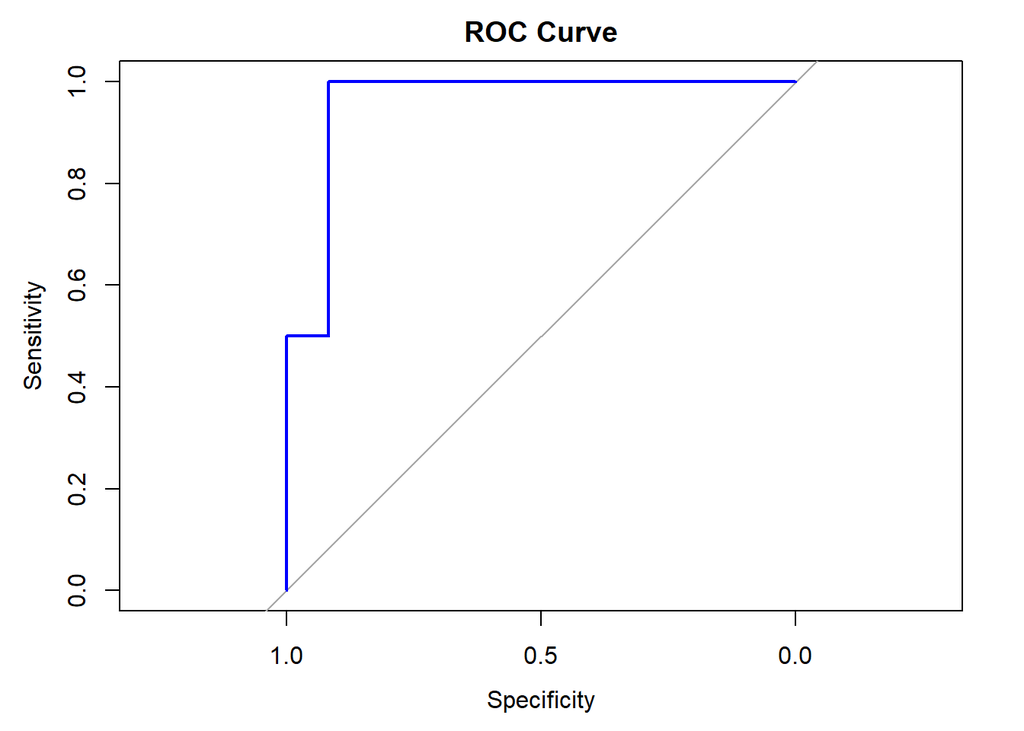

```
##
## Call:
## roc.default(response = test_data_scaled$feedback_type, predictor = pred_prob,     levels = c("1", "-1"), direction = ">")
##
## Data: pred_prob in 12 controls (test_data_scaled$feedback_type 1) > 6 cases (test_data_scaled$feedback_type -1).
## Area under the curve: 0.9583
```

```r
roc_result <- roc(test_data_scaled$feedback_type, pred_prob, levels = c("1", "-1"), direction = ">")
print(plot(roc_result, main = "ROC Curve", col = "blue", lwd = 2))
```